# Homework 6 Answer Key

Melinda K. Higgins, PhD.

November 22, 2017

For this homework we’ll use the `helpmkh` dataset.

Let’s focus on `g1b` as the main outcome variable experienced serious thoughts of suicide (last 30 days) - Baseline which is dichotomous coded 0 and 1.

We’ll use logistic regression to look at predicting whether someone had suicidal thoughts or not using these variables `age`, `female`, `pss_fr`, `pcs`, `mcs`, `cesd`, `homeless`, and `indtot`.

Initially just look at `cesd` as a continuous predictor.

Consider the continuous variable `cesd` as a predictor for `g1b` run a logistic regression of the probability of suicidal thoughts (`g1b`) given their depressive symptoms scores (`cesd`) make a plot of the the predicted probability of suicidal thoughts (`g1b`) by the depressive symptoms scores (`cesd`) what value of the `cesd` leads to a probability of suicidal thoughts => 0.5? *(hint: use the plot you just made)*

```r
# create subset of variables from helpmkh
h1 <- helpdat %>%
  select(g1b, age, female, pss_fr,
         homeless, pcs, mcs, cesd, indtot)
```

Logistic regression of `cesd` to predict the probability of `g1b`, suicidal thoughts we’ll also SAVE the predicted probabilities and the predicted group membership.

```r
m1 <- glm(g1b ~ cesd, data=h1,
          family=binomial)
```

## Model results

```r
m1
```

```
##
## Call:  glm(formula = g1b ~ cesd, family = binomial, data = h1)
##
## Coefficients:
## (Intercept)         cesd
##    -3.43335      0.07091
##
## Degrees of Freedom: 452 Total (i.e. Null);  451 Residual
## Null Deviance:       537.5
## Residual Deviance: 481.4     AIC: 485.4
```

```r
summary(m1)
```

```
##
## Call:
## glm(formula = g1b ~ cesd, family = binomial, data = h1)
##
## Deviance Residuals:
##     Min       1Q   Median       3Q      Max
## -1.4443  -0.8081  -0.5709   1.0716   2.1883
##
## Coefficients:
##             Estimate Std. Error z value Pr(>|z|)
## (Intercept) -3.43335    0.40434  -8.491  < 2e-16 ***
## cesd         0.07091    0.01049   6.762 1.36e-11 ***
## ---
## Signif. codes:  0 '***' 0.001 '**' 0.01 '*' 0.05 '.' 0.1 ' ' 1
##
## (Dispersion parameter for binomial family taken to be 1)
##
##     Null deviance: 537.52  on 452  degrees of freedom
## Residual deviance: 481.38  on 451  degrees of freedom
## AIC: 485.38
##
## Number of Fisher Scoring iterations: 4
```

Remember, in `R` you have to use the `exp()` function to get the odds ratios from the raw coefficients.

```r
kable(coef(m1),
      col.names = c("Raw Coefficients"),
      caption="Raw Coefficients",
      "html") %>%
  kable_styling(full_width = FALSE)
```

Raw Coefficients

|  | Raw Coefficients |
| --- | --- |
| (Intercept) | -3.433350 |
| cesd | 0.070911 |

```r
kable(exp(coef(m1)),
      col.names = c("Odds Ratios"),
      caption="Odds Ratios",
      "html") %>%
  kable_styling(full_width = FALSE)
```

Odds Ratios

|  | Odds Ratios |
| --- | --- |
| (Intercept) | 0.0322786 |
| cesd | 1.0734857 |

## Model predictions

Using the `predict()` function, get the predicted probabilities and plot them against the `cesd` as the predictor.

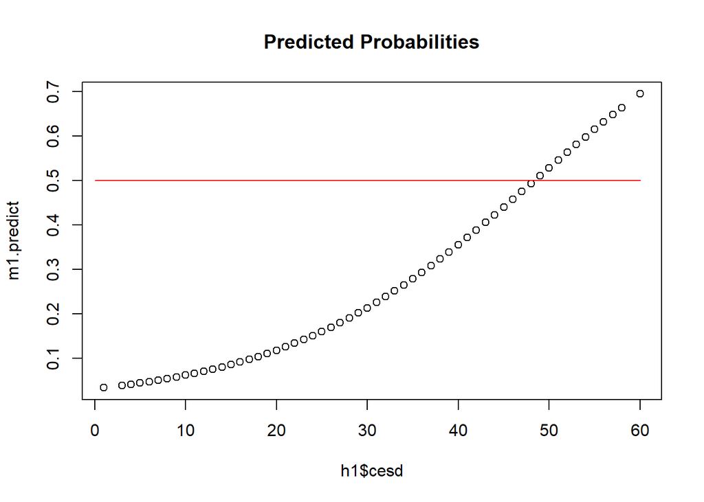

```r
m1.predict <- predict(m1, newdata=h1,
                      type="response")
plot(h1$cesd, m1.predict,
     main="Predicted Probabilities")
lines(c(0,60),c(0.5,0.5),col="red")
```

## Classification Table

The output below shows the results using the base R function `table()` and the `CrossTable()` function output from the `gmodels` package which we demonstrated in class. These initial tables used a cutoff threshold of 0.5.

```r
#confusion matrix
kable(table(h1$g1b, m1.predict > 0.5),
      caption="Confusion Matrix / Classification Table",
      "html") %>%
  kable_styling(full_width = FALSE)
```

Confusion Matrix / Classification Table

|  | FALSE | TRUE |
| --- | --- | --- |
| 0 | 299 | 27 |
| 1 | 103 | 24 |

```r
library(gmodels)
CrossTable(h1$g1b, m1.predict > 0.5)
```

```
##
##
##    Cell Contents
## |-------------------------|
## |                       N |
## | Chi-square contribution |
## |           N / Row Total |
## |           N / Col Total |
## |         N / Table Total |
## |-------------------------|
##
##
## Total Observations in Table:  453
##
##
##              | m1.predict > 0.5
##       h1$g1b |     FALSE |      TRUE | Row Total |
## -------------|-----------|-----------|-----------|
##            0 |       299 |        27 |       326 |
##              |     0.325 |     2.565 |           |
##              |     0.917 |     0.083 |     0.720 |
##              |     0.744 |     0.529 |           |
##              |     0.660 |     0.060 |           |
## -------------|-----------|-----------|-----------|
##            1 |       103 |        24 |       127 |
##              |     0.835 |     6.583 |           |
##              |     0.811 |     0.189 |     0.280 |
##              |     0.256 |     0.471 |           |
##              |     0.227 |     0.053 |           |
## -------------|-----------|-----------|-----------|
## Column Total |       402 |        51 |       453 |
##              |     0.887 |     0.113 |           |
## -------------|-----------|-----------|-----------|
##
##
```

Let’s also look at results for several other thresholds:

- predicted probability > 0.2

```r
CrossTable(h1$g1b, m1.predict > 0.2)
```

```
##
##
##    Cell Contents
## |-------------------------|
## |                       N |
## | Chi-square contribution |
## |           N / Row Total |
## |           N / Col Total |
## |         N / Table Total |
## |-------------------------|
##
##
## Total Observations in Table:  453
##
##
##              | m1.predict > 0.2
##       h1$g1b |     FALSE |      TRUE | Row Total |
## -------------|-----------|-----------|-----------|
##            0 |       137 |       189 |       326 |
##              |     6.182 |     3.184 |           |
##              |     0.420 |     0.580 |     0.720 |
##              |     0.890 |     0.632 |           |
##              |     0.302 |     0.417 |           |
## -------------|-----------|-----------|-----------|
##            1 |        17 |       110 |       127 |
##              |    15.868 |     8.173 |           |
##              |     0.134 |     0.866 |     0.280 |
##              |     0.110 |     0.368 |           |
##              |     0.038 |     0.243 |           |
## -------------|-----------|-----------|-----------|
## Column Total |       154 |       299 |       453 |
##              |     0.340 |     0.660 |           |
## -------------|-----------|-----------|-----------|
##
##
```

- predicted probability > 0.4

```r
CrossTable(h1$g1b, m1.predict > 0.4)
```

```
##
##
##    Cell Contents
## |-------------------------|
## |                       N |
## | Chi-square contribution |
## |           N / Row Total |
## |           N / Col Total |
## |         N / Table Total |
## |-------------------------|
##
##
## Total Observations in Table:  453
##
##
##              | m1.predict > 0.4
##       h1$g1b |     FALSE |      TRUE | Row Total |
## -------------|-----------|-----------|-----------|
##            0 |       271 |        55 |       326 |
##              |     1.133 |     3.999 |           |
##              |     0.831 |     0.169 |     0.720 |
##              |     0.768 |     0.550 |           |
##              |     0.598 |     0.121 |           |
## -------------|-----------|-----------|-----------|
##            1 |        82 |        45 |       127 |
##              |     2.908 |    10.266 |           |
##              |     0.646 |     0.354 |     0.280 |
##              |     0.232 |     0.450 |           |
##              |     0.181 |     0.099 |           |
## -------------|-----------|-----------|-----------|
## Column Total |       353 |       100 |       453 |
##              |     0.779 |     0.221 |           |
## -------------|-----------|-----------|-----------|
##
##
```

- predicted probability > 0.6

```r
CrossTable(h1$g1b, m1.predict > 0.6)
```

```
##
##
##    Cell Contents
## |-------------------------|
## |                       N |
## | Chi-square contribution |
## |           N / Row Total |
## |           N / Col Total |
## |         N / Table Total |
## |-------------------------|
##
##
## Total Observations in Table:  453
##
##
##              | m1.predict > 0.6
##       h1$g1b |     FALSE |      TRUE | Row Total |
## -------------|-----------|-----------|-----------|
##            0 |       322 |         4 |       326 |
##              |     0.091 |     3.066 |           |
##              |     0.988 |     0.012 |     0.720 |
##              |     0.732 |     0.308 |           |
##              |     0.711 |     0.009 |           |
## -------------|-----------|-----------|-----------|
##            1 |       118 |         9 |       127 |
##              |     0.233 |     7.869 |           |
##              |     0.929 |     0.071 |     0.280 |
##              |     0.268 |     0.692 |           |
##              |     0.260 |     0.020 |           |
## -------------|-----------|-----------|-----------|
## Column Total |       440 |        13 |       453 |
##              |     0.971 |     0.029 |           |
## -------------|-----------|-----------|-----------|
##
##
```

- predicted probability > 0.8

```r
CrossTable(h1$g1b, m1.predict > 0.8)
```

```
##
##
##    Cell Contents
## |-------------------------|
## |                       N |
## |         N / Table Total |
## |-------------------------|
##
##
## Total Observations in Table:  453
##
##
##              | m1.predict > 0.8
##       h1$g1b |     FALSE | Row Total |
## -------------|-----------|-----------|
##            0 |       326 |       326 |
##              |     0.720 |           |
## -------------|-----------|-----------|
##            1 |       127 |       127 |
##              |     0.280 |           |
## -------------|-----------|-----------|
## Column Total |       453 |       453 |
## -------------|-----------|-----------|
##
##
```

## Make a ROC (receiver operating characteristic) curve

You can see an online example at https://www.r-bloggers.com/how-to-perform-a-logistic-regression-in-r/

```r
library(ROCR)
```

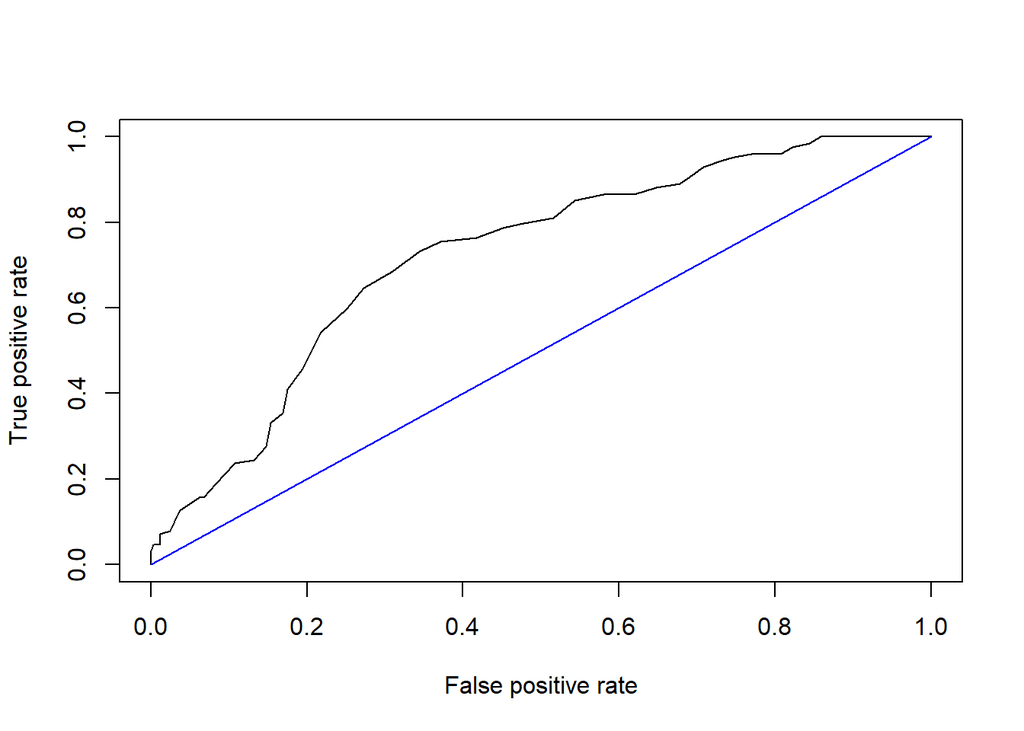

```r
p <- predict(m1, newdata=h1,
             type="response")
pr <- prediction(p, as.numeric(h1$g1b))
prf <- performance(pr, measure = "tpr", x.measure = "fpr")
plot(prf)
lines(c(0,1),c(0,1),col="blue")
```

## AUC - Area Under the Curve statistic

We can also compute the area under the curve (AUC) - the closer to 1 the better the model predictions.

```r
auc <- performance(pr, measure = "auc")
auc <- auc@y.values[[1]]
auc
```

```
## [1] 0.7227429
```

## Variable Selection

Using variable selection methods, develop a logistic regression model for the probability of suicidal thoughts (`g1b`) considering all of these variables for possible inclusion: `age`, `female`, `pss_fr`, `homeless`, `pcs`, `mcs`, `cesd`, `indtot`.

Look at all variables in the model together without any variable selection. The significant variables are:

- `female`
- `homeless`
- `mcs`
- `cesd`

```r
# run the logistic regression entering all
# variables at once
m2 <- glm(g1b ~ ., data=h1, family=binomial)
summary(m2)
```

```
##
## Call:
## glm(formula = g1b ~ ., family = binomial, data = h1)
##
## Deviance Residuals:
##     Min       1Q   Median       3Q      Max
## -1.6584  -0.7946  -0.5152   0.9239   2.3715
##
## Coefficients:
##              Estimate Std. Error z value Pr(>|z|)
## (Intercept) -0.880372   1.594090  -0.552  0.58076
## age         -0.028233   0.015547  -1.816  0.06938 .
## female       0.696841   0.288047   2.419  0.01555 *
## pss_fr      -0.005106   0.030422  -0.168  0.86670
## homeless     0.529576   0.240341   2.203  0.02756 *
## pcs         -0.016347   0.011765  -1.389  0.16469
## mcs         -0.037111   0.013825  -2.684  0.00727 **
## cesd         0.035462   0.014040   2.526  0.01154 *
## indtot       0.031003   0.022454   1.381  0.16735
## ---
## Signif. codes:  0 '***' 0.001 '**' 0.01 '*' 0.05 '.' 0.1 ' ' 1
##
## (Dispersion parameter for binomial family taken to be 1)
##
##     Null deviance: 537.52  on 452  degrees of freedom
## Residual deviance: 455.35  on 444  degrees of freedom
## AIC: 473.35
##
## Number of Fisher Scoring iterations: 5
```

## Variable selection

You could simply choose to keep the significant variables, which were `female`, `homeless`, `mcs` and `cesd`.

However, there are some variable selection approaches in `R`. In base `R` you can use the `step()` function.

```r
# OPTIONAL - NOT COVERED IN CLASS
# ==========================================
# stepwise variable selection using step()
m0 <- glm(g1b ~ 1, data=h1, family=binomial)
m1 <- glm(g1b ~ ., data=h1, family=binomial)
step(m0,scope=formula(m1),direction="forward",k=2) # AIC
```

```
## Start:  AIC=539.52
## g1b ~ 1
##
##            Df Deviance    AIC
## + cesd      1   481.38 485.38
## + mcs       1   487.23 491.23
## + indtot    1   522.59 526.59
## + pcs       1   527.69 531.69
## + female    1   527.73 531.73
## + homeless  1   529.61 533.61
## + pss_fr    1   533.76 537.76
## <none>          537.52 539.52
## + age       1   536.07 540.07
##
## Step:  AIC=485.38
## g1b ~ cesd
##
##            Df Deviance    AIC
## + mcs       1   472.66 478.66
## + homeless  1   476.00 482.00
## + female    1   478.14 484.14
## + indtot    1   478.39 484.39
## + age       1   479.05 485.05
## <none>          481.38 485.38
## + pcs       1   480.06 486.06
## + pss_fr    1   480.88 486.88
##
## Step:  AIC=478.66
## g1b ~ cesd + mcs
##
##            Df Deviance    AIC
## + homeless  1   467.01 475.01
## + female    1   469.20 477.20
## + pcs       1   469.94 477.94
## <none>          472.66 478.66
## + age       1   470.90 478.90
## + indtot    1   471.28 479.28
## + pss_fr    1   472.12 480.12
##
## Step:  AIC=475.01
```

[output cut: 21 more lines]

```
## g1b ~ cesd + mcs + homeless + female + indtot
##
##          Df Deviance    AIC
## + age     1   457.32 471.32
## <none>        459.69 471.69
## + pcs     1   458.79 472.79
## + pss_fr  1   459.61 473.61
##
## Step:  AIC=471.32
## g1b ~ cesd + mcs + homeless + female + indtot + age
##
##          Df Deviance    AIC
## <none>        457.32 471.32
## + pcs     1   455.38 471.38
## + pss_fr  1   457.28 473.28
```

```
##
## Call:  glm(formula = g1b ~ cesd + mcs + homeless + female + indtot +
##     age, family = binomial, data = h1)
##
## Coefficients:
## (Intercept)         cesd          mcs     homeless       female
##    -2.32289      0.04067     -0.03343      0.56484      0.76358
##      indtot          age
##     0.03442     -0.02291
##
## Degrees of Freedom: 452 Total (i.e. Null);  446 Residual
## Null Deviance:       537.5
## Residual Deviance: 457.3     AIC: 471.3
```

A slightly improved version of the `step()` function is the `stepAIC()` function from the `MASS` package. There are several `IC` options for the information criterion for variable selection. The code below shows how to run the code using the AIC criterion or the BIC criterion - with `forward` variable selection.

### AIC Criterion - forward variable selection

```r
library(MASS)
stepAIC(m0,scope=formula(m1),direction="forward",k=2) #AIC criterion
```

```
## Start:  AIC=539.52
## g1b ~ 1
##
##            Df Deviance    AIC
## + cesd      1   481.38 485.38
## + mcs       1   487.23 491.23
## + indtot    1   522.59 526.59
## + pcs       1   527.69 531.69
## + female    1   527.73 531.73
## + homeless  1   529.61 533.61
## + pss_fr    1   533.76 537.76
## <none>          537.52 539.52
## + age       1   536.07 540.07
##
## Step:  AIC=485.38
## g1b ~ cesd
##
##            Df Deviance    AIC
## + mcs       1   472.66 478.66
## + homeless  1   476.00 482.00
## + female    1   478.14 484.14
## + indtot    1   478.39 484.39
## + age       1   479.05 485.05
## <none>          481.38 485.38
## + pcs       1   480.06 486.06
## + pss_fr    1   480.88 486.88
##
## Step:  AIC=478.66
## g1b ~ cesd + mcs
##
##            Df Deviance    AIC
## + homeless  1   467.01 475.01
## + female    1   469.20 477.20
## + pcs       1   469.94 477.94
## <none>          472.66 478.66
## + age       1   470.90 478.90
## + indtot    1   471.28 479.28
## + pss_fr    1   472.12 480.12
##
## Step:  AIC=475.01
```

[output cut: 21 more lines]

```
## g1b ~ cesd + mcs + homeless + female + indtot
##
##          Df Deviance    AIC
## + age     1   457.32 471.32
## <none>        459.69 471.69
## + pcs     1   458.79 472.79
## + pss_fr  1   459.61 473.61
##
## Step:  AIC=471.32
## g1b ~ cesd + mcs + homeless + female + indtot + age
##
##          Df Deviance    AIC
## <none>        457.32 471.32
## + pcs     1   455.38 471.38
## + pss_fr  1   457.28 473.28
```

```
##
## Call:  glm(formula = g1b ~ cesd + mcs + homeless + female + indtot +
##     age, family = binomial, data = h1)
##
## Coefficients:
## (Intercept)         cesd          mcs     homeless       female
##    -2.32289      0.04067     -0.03343      0.56484      0.76358
##      indtot          age
##     0.03442     -0.02291
##
## Degrees of Freedom: 452 Total (i.e. Null);  446 Residual
## Null Deviance:       537.5
## Residual Deviance: 457.3     AIC: 471.3
```

### BIC criterion - forward variable selection

```r
n <- 453 # get sample size
stepAIC(m0,scope=formula(m1),direction="forward",k=log(n)) #BIC criterion
```

```
## Start:  AIC=543.63
## g1b ~ 1
##
##            Df Deviance    AIC
## + cesd      1   481.38 493.61
## + mcs       1   487.23 499.46
## + indtot    1   522.59 534.82
## + pcs       1   527.69 539.92
## + female    1   527.73 539.96
## + homeless  1   529.61 541.84
## <none>          537.52 543.63
## + pss_fr    1   533.76 545.99
## + age       1   536.07 548.31
##
## Step:  AIC=493.61
## g1b ~ cesd
##
##            Df Deviance    AIC
## + mcs       1   472.66 491.01
## <none>          481.38 493.61
## + homeless  1   476.00 494.35
## + female    1   478.14 496.49
## + indtot    1   478.39 496.74
## + age       1   479.05 497.39
## + pcs       1   480.06 498.41
## + pss_fr    1   480.88 499.23
##
## Step:  AIC=491.01
## g1b ~ cesd + mcs
##
##            Df Deviance    AIC
## <none>          472.66 491.01
## + homeless  1   467.01 491.47
## + female    1   469.20 493.67
## + pcs       1   469.94 494.41
## + age       1   470.90 495.37
## + indtot    1   471.28 495.74
## + pss_fr    1   472.12 496.59
```

```
##
## Call:  glm(formula = g1b ~ cesd + mcs, family = binomial, data = h1)
##
## Coefficients:
## (Intercept)         cesd          mcs
##    -1.54986      0.04811     -0.03705
##
## Degrees of Freedom: 452 Total (i.e. Null);  450 Residual
## Null Deviance:       537.5
## Residual Deviance: 472.7     AIC: 478.7
```

### AIC Criterion - both (forward and backward) variable selection

```r
# try both
stepAIC(m0,scope=formula(m1),direction="both",k=2) #AIC
```

```
## Start:  AIC=539.52
## g1b ~ 1
##
##            Df Deviance    AIC
## + cesd      1   481.38 485.38
## + mcs       1   487.23 491.23
## + indtot    1   522.59 526.59
## + pcs       1   527.69 531.69
## + female    1   527.73 531.73
## + homeless  1   529.61 533.61
## + pss_fr    1   533.76 537.76
## <none>          537.52 539.52
## + age       1   536.07 540.07
##
## Step:  AIC=485.38
## g1b ~ cesd
##
##            Df Deviance    AIC
## + mcs       1   472.66 478.66
## + homeless  1   476.00 482.00
## + female    1   478.14 484.14
## + indtot    1   478.39 484.39
## + age       1   479.05 485.05
## <none>          481.38 485.38
## + pcs       1   480.06 486.06
## + pss_fr    1   480.88 486.88
## - cesd      1   537.52 539.52
##
## Step:  AIC=478.66
## g1b ~ cesd + mcs
##
##            Df Deviance    AIC
## + homeless  1   467.01 475.01
## + female    1   469.20 477.20
## + pcs       1   469.94 477.94
## <none>          472.66 478.66
## + age       1   470.90 478.90
## + indtot    1   471.28 479.28
## + pss_fr    1   472.12 480.12
## - mcs       1   481.38 485.38
```

[output cut: 42 more lines]

```
## - cesd      1   468.70 478.70
##
## Step:  AIC=471.32
## g1b ~ cesd + mcs + homeless + female + indtot + age
##
##            Df Deviance    AIC
## <none>          457.32 471.32
## + pcs       1   455.38 471.38
## - age       1   459.69 471.69
## - indtot    1   459.85 471.85
## + pss_fr    1   457.28 473.28
## - homeless  1   463.09 475.09
## - mcs       1   463.79 475.79
## - female    1   464.55 476.55
## - cesd      1   466.84 478.84
```

```
##
## Call:  glm(formula = g1b ~ cesd + mcs + homeless + female + indtot +
##     age, family = binomial, data = h1)
##
## Coefficients:
## (Intercept)         cesd          mcs     homeless       female
##    -2.32289      0.04067     -0.03343      0.56484      0.76358
##      indtot          age
##     0.03442     -0.02291
##
## Degrees of Freedom: 452 Total (i.e. Null);  446 Residual
## Null Deviance:       537.5
## Residual Deviance: 457.3     AIC: 471.3
```

In general variable selection methods are problematic for many reasons some of which include low power and selection biases that occur depending on the algorithms used. I encourage you to read more on LASSO (least absolute shrinkage and selection operator) approaches, see https://en.wikipedia.org/wiki/Lasso_(statistics) and Rob Tibshirani’s website on the LASSO approach he developed http://statweb.stanford.edu/~tibs/lasso.html.

That said, there is also a package called `bestglm` which has a main function `bestglm()` that employs several different algorithms and information criteria for selecting variables. The examples below show how to select variables based on the AIC criterion and based on using CV which is a cross-validation approach - read more in the help for bestglm [`help(bestglm)`].

### Basic `bestglm()` variable selection approach

Notice the data has to be restructured slightly for the function to run.

```r
# try bestglm package
# create Xy dataset
# X should contain the vars
# you want to select among
# and the last column should be y the outcome
X <- h1[,2:9]
y <- h1$g1b

library(bestglm)
Xy <- cbind(X,y)
out <- bestglm(Xy)
out
```

```
## BIC
## BICq equivalent for q in (0.375973572294526, 0.564904492466229)
## Best Model:
##                 Estimate  Std. Error   t value     Pr(>|t|)
## (Intercept)  0.190934366 0.127978892  1.491921 0.1364206099
## mcs         -0.005634091 0.002108794 -2.671713 0.0078202946
## cesd         0.008155465 0.002163539  3.769503 0.0001853623
```

### AIC `bestglm()` variable selection approach

```r
# bestglm uses the BIC criterion for selection
# by default, you can try other information
# criterion also like AIC or CV (cross validation)
bestglm(Xy, IC="AIC")
```

```
## AIC
## BICq equivalent for q in (0.879954087774943, 0.910547039038517)
## Best Model:
##                 Estimate  Std. Error   t value    Pr(>|t|)
## (Intercept)  0.484375048 0.210507661  2.300985 0.021852857
## age         -0.004695654 0.002619781 -1.792384 0.073749091
## female       0.109183422 0.047421541  2.302401 0.021772212
## homeless     0.104530496 0.039865480  2.622080 0.009038436
## pcs         -0.002872066 0.001980074 -1.450484 0.147626412
## mcs         -0.005729510 0.002101652 -2.726193 0.006659301
## cesd         0.006358688 0.002252038  2.823526 0.004962526
```

### CV `bestglm()` variable selection approach

Note: The corss-validation approach runs through several selection options, so this option takes a few minutes to run.

```r
bestglm(Xy, IC="CV")
```

```
## CVd(d = 365, REP = 1000)
## BICq equivalent for q in (0.375973572294539, 0.564904492466222)
## Best Model:
##                 Estimate  Std. Error   t value     Pr(>|t|)
## (Intercept)  0.190934366 0.127978892  1.491921 0.1364206099
## mcs         -0.005634091 0.002108794 -2.671713 0.0078202946
## cesd         0.008155465 0.002163539  3.769503 0.0001853623
```